# R MarkDown - Rain Forecast Project

Alexandre Marette

31 aout 2019

# Etape 0 - Nettoyage de l’environnement

```r
rm(list=ls())
list=ls()
```

# Etape 1 - Import du fichier de training

```r
train_meteo = read.csv("meteo.train.csv", na.strings = "")
```

# Etape 2 - Nettoyage et selection des donnees

```r
#Installation du package questionr
#install.packages("questionr")
library(questionr)

View(train_meteo)
#summary(train_meteo)
names(train_meteo)
```

```
##  [1] "X"
##  [2] "Year"
##  [3] "Month"
##  [4] "Day"
##  [5] "Hour"
##  [6] "Minute"
##  [7] "Temperature.daily.mean..2.m.above.gnd."
##  [8] "Relative.Humidity.daily.mean..2.m.above.gnd."
##  [9] "Mean.Sea.Level.Pressure.daily.mean..MSL."
## [10] "Total.Precipitation.daily.sum..sfc."
## [11] "Snowfall.amount.raw.daily.sum..sfc."
## [12] "Total.Cloud.Cover.daily.mean..sfc."
## [13] "High.Cloud.Cover.daily.mean..high.cld.lay."
## [14] "Medium.Cloud.Cover.daily.mean..mid.cld.lay."
## [15] "Low.Cloud.Cover.daily.mean..low.cld.lay."
```

[output cut: 32 more lines]

```r
attach(train_meteo)

#Verification pas de ligne vide
freq(train_meteo$pluie.demain)
```

```
##         n    % val%
## FALSE 625 50.2 50.2
## TRUE  619 49.8 49.8
```

```r
#levels(train_meteo$pluie.demain)
#Calcul du nombre de lignes et de colonnes dans le fichier
nb_lignes = nrow(train_meteo)
nb_colonnes = ncol
```

## Suppression des colonnes heures et minutes (ne contiennent que des valeurs nulles)

```r
tr_meteo = cbind(train_meteo[,1:4],train_meteo[,7:ncol(train_meteo)])
attach(tr_meteo)
```

## Etude des correlations entre les variables explicatives

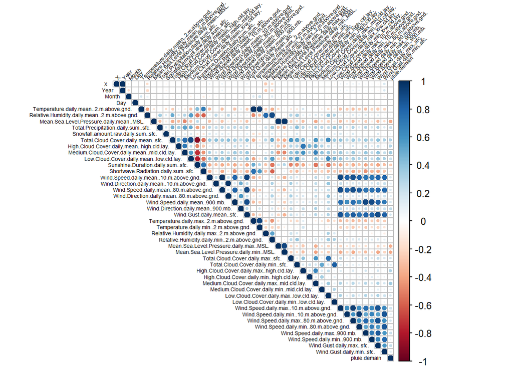

```r
matrice_cor = cor(tr_meteo,method = c("pearson"))
plot.new()
corrplot(matrice_cor, type="upper", order="original",
         tl.col="black", tl.srt=45,tl.cex = 0.45)
```

En premiere approche, on remarque que les variables de vitesse du vent sont correlees positivement entre elles. Les co-variables de temperatures egalement, ainsi que certaines donnees relatives a l humidite et a la pression.

### Essayons d’etudier ces correlations plus en detail :

a- D’abord la vitesse et la direction du vent :

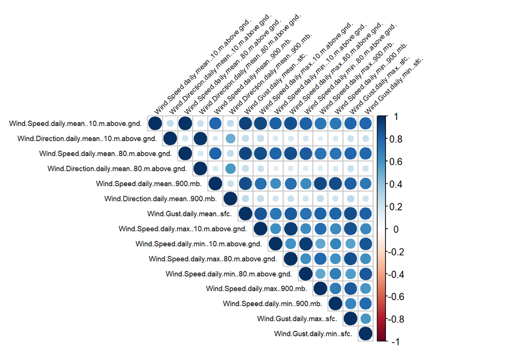

```r
#selection des variables :
tr_wind = cbind(tr_meteo[,16:22],tr_meteo[,37:44])
# calcul de la matrice de correlation
cor_wind=cor(tr_wind,method = c("pearson"))
# Graph de la matrice de corrÃ©lation
plot.new()
corrplot(cor_wind, type="upper", order="original",
         tl.col="black", tl.srt=45,tl.cex = 0.6)
```

- les variables concernant le vent les moins correlees aux autres sont les variables de direction moyenne => Nous allons les conserver.
- Les variables de vitesse du vent sont toutes correlees entre elles. => Nous allons tester en ne prenant que les valeurs moyennes.

b- Analyse des correlations sur les temperatures, l’humidite et la pression

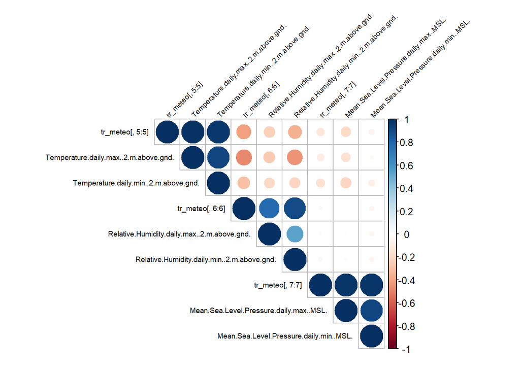

```r
tr_tHp = cbind(tr_meteo[,5:5],tr_meteo[,23:24],tr_meteo[,6:6],tr_meteo[,25:26],tr_meteo[,7:7],tr_meteo[,27:28])
cor_tHp = cor(tr_tHp,method = c("pearson"))
plot.new()
corrplot(cor_tHp, type="upper", order="original",
         tl.col="black", tl.srt=45,tl.cex = 0.6)
```

Cette analyse conforte les conclusions precedentes. Nous allons tester en prenant les variables moyennes.

## Construction du dataset a partir des resultats precedents :

- Nous allons eliminer les variables temporelles qui ne nous paraissent pas apporter d’information particuliere dans le cadre de ce projet, meme si on peut se poser la question d’une tendance et de la probabilite de pluie si la veille il a plu. Mais cela semble sortir du cadre de ce cours.
- Nous conservons les variables de direction moyennes du vent et de vitesse moyennes du vent.
- Nous conservons les variables moyennes d’humidite, de temperatures et de pression.

```r
t_meteo = cbind(tr_meteo[,1],tr_meteo[,5:22],tr_meteo[,29:36],tr_meteo[,45])
names(t_meteo)[1]="X"
names(t_meteo)[28]="pluie.demain"
```

# Etape 3 - Preparation de la Validation Croisee : creation du jeu de donnee d’entrainement et du jeu de test

On cree un vecteurs de booleens, tires aleatoirement : - les valeurs TRUE correspondent aux individus de la base d’entrainement - les valeurs FALSE correspondent aux individus de la base de test

```r
train = sample(c(T, F), nrow(t_meteo), replace = T, prob = c(.75, .25))
length(train)
```

```
## [1] 1244
```

```r
nrow(t_meteo)
```

```
## [1] 1244
```

```r
names(t_meteo)
```

```
##  [1] "X"
##  [2] "Temperature.daily.mean..2.m.above.gnd."
##  [3] "Relative.Humidity.daily.mean..2.m.above.gnd."
##  [4] "Mean.Sea.Level.Pressure.daily.mean..MSL."
##  [5] "Total.Precipitation.daily.sum..sfc."
##  [6] "Snowfall.amount.raw.daily.sum..sfc."
##  [7] "Total.Cloud.Cover.daily.mean..sfc."
##  [8] "High.Cloud.Cover.daily.mean..high.cld.lay."
##  [9] "Medium.Cloud.Cover.daily.mean..mid.cld.lay."
## [10] "Low.Cloud.Cover.daily.mean..low.cld.lay."
## [11] "Sunshine.Duration.daily.sum..sfc."
## [12] "Shortwave.Radiation.daily.sum..sfc."
## [13] "Wind.Speed.daily.mean..10.m.above.gnd."
## [14] "Wind.Direction.daily.mean..10.m.above.gnd."
## [15] "Wind.Speed.daily.mean..80.m.above.gnd."
## [16] "Wind.Direction.daily.mean..80.m.above.gnd."
## [17] "Wind.Speed.daily.mean..900.mb."
## [18] "Wind.Direction.daily.mean..900.mb."
## [19] "Wind.Gust.daily.mean..sfc."
## [20] "Total.Cloud.Cover.daily.max..sfc."
## [21] "Total.Cloud.Cover.daily.min..sfc."
## [22] "High.Cloud.Cover.daily.max..high.cld.lay."
## [23] "High.Cloud.Cover.daily.min..high.cld.lay."
## [24] "Medium.Cloud.Cover.daily.max..mid.cld.lay."
## [25] "Medium.Cloud.Cover.daily.min..mid.cld.lay."
## [26] "Low.Cloud.Cover.daily.max..low.cld.lay."
## [27] "Low.Cloud.Cover.daily.min..low.cld.lay."
## [28] "pluie.demain"
```

# Etape 4 - Construction du modele et choix du modele

## Echauffement : une premiere regression de test avec l’ensemble des variables

### Premiere regression logit binaire sur l’ensemble des variables explicatives

```r
reg <- glm(pluie.demain ~ .,
           data = t_meteo[train,], family = binomial(logit))
summary(reg)
```

```
##
## Call:
## glm(formula = pluie.demain ~ ., family = binomial(logit), data = t_meteo[train,
##     ])
##
## Deviance Residuals:
##     Min       1Q   Median       3Q      Max
## -2.8037  -0.8793   0.1383   0.9306   2.3036
##
## Coefficients:
##                                                Estimate Std. Error z value
## (Intercept)                                   7.998e+01  1.329e+01   6.017
## X                                             2.186e-05  9.477e-05   0.231
## Temperature.daily.mean..2.m.above.gnd.        5.622e-03  1.887e-02   0.298
## Relative.Humidity.daily.mean..2.m.above.gnd.  7.629e-03  1.231e-02   0.620
## Mean.Sea.Level.Pressure.daily.mean..MSL.     -8.042e-02  1.295e-02  -6.208
## Total.Precipitation.daily.sum..sfc.           6.625e-03  2.808e-02   0.236
## Snowfall.amount.raw.daily.sum..sfc.           4.993e-01  4.469e-01   1.117
## Total.Cloud.Cover.daily.mean..sfc.           -4.094e-04  1.342e-02  -0.031
## High.Cloud.Cover.daily.mean..high.cld.lay.    1.545e-02  7.711e-03   2.004
## Medium.Cloud.Cover.daily.mean..mid.cld.lay.  -6.336e-03  7.486e-03  -0.846
## Low.Cloud.Cover.daily.mean..low.cld.lay.      2.065e-03  9.334e-03   0.221
## Sunshine.Duration.daily.sum..sfc.            -4.654e-04  9.514e-04  -0.489
## Shortwave.Radiation.daily.sum..sfc.           3.762e-05  9.141e-05   0.412
## Wind.Speed.daily.mean..10.m.above.gnd.        3.461e-02  7.889e-02   0.439
## Wind.Direction.daily.mean..10.m.above.gnd.    4.712e-03  5.779e-03   0.815
## Wind.Speed.daily.mean..80.m.above.gnd.       -1.089e-01  5.852e-02  -1.860
## Wind.Direction.daily.mean..80.m.above.gnd.   -7.206e-03  5.954e-03  -1.210
## Wind.Speed.daily.mean..900.mb.                2.752e-03  1.159e-02   0.237
## Wind.Direction.daily.mean..900.mb.            5.313e-03  1.496e-03   3.552
## Wind.Gust.daily.mean..sfc.                    5.988e-02  2.735e-02   2.189
## Total.Cloud.Cover.daily.max..sfc.            -4.434e-03  5.347e-03  -0.829
## Total.Cloud.Cover.daily.min..sfc.             2.131e-02  1.133e-02   1.881
## High.Cloud.Cover.daily.max..high.cld.lay.     7.949e-05  3.051e-03   0.026
## High.Cloud.Cover.daily.min..high.cld.lay.    -4.807e-02  3.118e-02  -1.542
## Medium.Cloud.Cover.daily.max..mid.cld.lay.    1.256e-02  3.494e-03   3.596
## Medium.Cloud.Cover.daily.min..mid.cld.lay.    4.678e-03  1.206e-02   0.388
## Low.Cloud.Cover.daily.max..low.cld.lay.      -3.421e-04  3.669e-03  -0.093
## Low.Cloud.Cover.daily.min..low.cld.lay.      -2.353e-02  1.107e-02  -2.127
##                                              Pr(>|z|)
```

[output cut: 23 more lines]

```
## High.Cloud.Cover.daily.min..high.cld.lay.    0.123140
## Medium.Cloud.Cover.daily.max..mid.cld.lay.   0.000324 ***
## Medium.Cloud.Cover.daily.min..mid.cld.lay.   0.698165
## Low.Cloud.Cover.daily.max..low.cld.lay.      0.925728
## Low.Cloud.Cover.daily.min..low.cld.lay.      0.033449 *
## ---
## Signif. codes:  0 '***' 0.001 '**' 0.01 '*' 0.05 '.' 0.1 ' ' 1
##
## (Dispersion parameter for binomial family taken to be 1)
##
##     Null deviance: 1307.2  on 942  degrees of freedom
## Residual deviance: 1040.9  on 915  degrees of freedom
## AIC: 1096.9
##
## Number of Fisher Scoring iterations: 6
```

```r
#Calcul des VIF entre les covariables  :
library(faraway)
#install.packages("fmsb")
vif(reg)
```

```
##                                            X
##                                     5.955415
##       Temperature.daily.mean..2.m.above.gnd.
##                                    17.020373
## Relative.Humidity.daily.mean..2.m.above.gnd.
##                                    12.818361
##     Mean.Sea.Level.Pressure.daily.mean..MSL.
##                                     9.938744
##          Total.Precipitation.daily.sum..sfc.
##                                    13.146408
##          Snowfall.amount.raw.daily.sum..sfc.
##                                    77.322090
##           Total.Cloud.Cover.daily.mean..sfc.
##                                   167.163379
##   High.Cloud.Cover.daily.mean..high.cld.lay.
##                                    24.232768
##  Medium.Cloud.Cover.daily.mean..mid.cld.lay.
##                                    44.920467
##     Low.Cloud.Cover.daily.mean..low.cld.lay.
##                                    78.838141
##            Sunshine.Duration.daily.sum..sfc.
##                                    65.115719
##          Shortwave.Radiation.daily.sum..sfc.
##                                    35.263226
##       Wind.Speed.daily.mean..10.m.above.gnd.
##                                   215.923670
##   Wind.Direction.daily.mean..10.m.above.gnd.
##                                   119.047481
##       Wind.Speed.daily.mean..80.m.above.gnd.
##                                   199.234710
##   Wind.Direction.daily.mean..80.m.above.gnd.
##                                   129.118339
##               Wind.Speed.daily.mean..900.mb.
##                                    31.605667
##           Wind.Direction.daily.mean..900.mb.
##                                    11.830050
##                   Wind.Gust.daily.mean..sfc.
##                                    74.879658
##            Total.Cloud.Cover.daily.max..sfc.
##                                    22.275703
##            Total.Cloud.Cover.daily.min..sfc.
##                                    65.108409
##    High.Cloud.Cover.daily.max..high.cld.lay.
##                                    15.881050
##    High.Cloud.Cover.daily.min..high.cld.lay.
##                                     8.498436
##   Medium.Cloud.Cover.daily.max..mid.cld.lay.
##                                    19.687484
##   Medium.Cloud.Cover.daily.min..mid.cld.lay.
##                                    13.943097
##      Low.Cloud.Cover.daily.max..low.cld.lay.
##                                    18.002846
##      Low.Cloud.Cover.daily.min..low.cld.lay.
##                                    41.652928
```

Les variables sont tres correlees entre elles, nous avons donc un probleme de multicolinearite dans le modele reg.

```r
# Le test par rapport au modÃ¨le sans covariable donne
pchisq(1297.5 - 1017.0, 935 - 908, lower = F)
```

```
## [1] 5.414596e-44
```

=> p-valeur tres faible : on rejette le modele sans covariable

```r
# Le test par rapport au modÃ¨le saturÃ© donne
pchisq(1297.5, 908, lower = F)
```

```
## [1] 2.714135e-16
```

=> p-valeur est faible : notre modele ne suffit pas a expliquer toutes les variations. Il est mal ajuste.